# Shiny

April 30, 2015

## Opening Credits

- Presentation Created with ioslides
- Using R Studio
- All the Source Code is Available Online*

**You should still pay attention*

## Goals

*You will…*

- Publish a Shiny App Tonight
- Update Your App *(and be able to do that at your leisure)*
- Know Where to Find Information for Expanding Your App
- Be Able to Build New Apps
- See How Versatile, Shiny Really Is…
- Peek into the Future to See What Shiny Will Offer…

*…assuming the Internet God's allow it*

## Shiny

### What is it?

*It's simple! Shiny is a…*

### **Framework for creating Web-based, Interactive, R Applications**

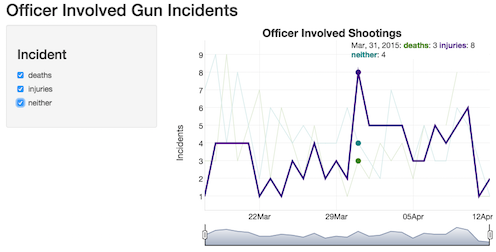

*I could have darned my socks - is this how this is going to go?*

## Screenshot: Shiny Example

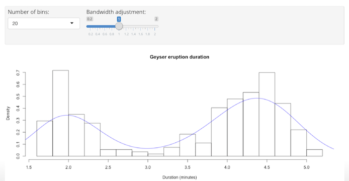

## Why do I need it?

### What problems does an interactive application (vs. static images) solve?

### Philanthropy / Altrusism

- Train / teach others
- Give back to the community
- Start a dialog about an important topic
- Allow others to research your dataset
- Create a shared experience

### Self-Promotion / Ego

- Improve your own Knowledge / Judgement
- Develop Professional Contacts
- Become *"FAMOUS"*
- Show off a Novel Idea / Observation
- Pursuade others with your data set

## Pursuade Others

### Static Example

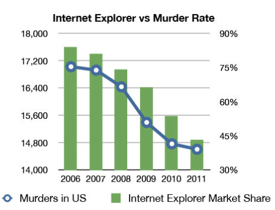

## Blather on about the Shiny App

- UI shields you from JS / CSS / HTML (*easy to build*)
- UI and Server are built as separate functions (*simple to maintain*)
- Based on Twitter Bootstrap (*it'll run on your phone*)
- Requires a Shiny Server (*bummer*)
- The example was **STOLEN** from http://rmarkdown.rstudio.com/authoring_shiny.html

## Source Code: UI

```r
inputPanel(
  selectInput(
    "n_breaks",
     label = "Number of bins:",
     choices = c(10, 20, 35, 50), selected = 20),

  sliderInput(
    "bw_adjust",
     label = "Bandwidth adjustment:",
     min = 0.2, max = 2, value = 1, step = 0.2)
)
```

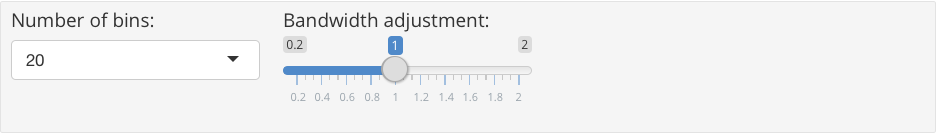

## Available Inputs

### I need to know what's possible

http://shiny.rstudio.com/gallery/widget-gallery.html

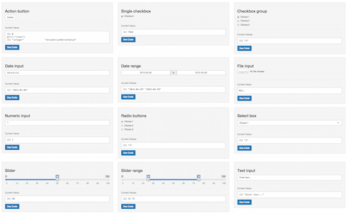

## Source Code: Server

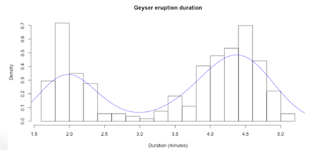

```r
renderPlot({
  hist(faithful$eruptions, probability = TRUE,
       breaks = as.numeric(input$n_breaks),
       xlab = "Duration (minutes)",
       main = "Geyser eruption duration")
  dens <- density(faithful$eruptions, adjust = input$bw_adjust)
  lines(dens, col = "blue")
})
```

## I. Mission: Publish a Shiny App

## Installation: Shiny

http://shiny.rstudio.com/tutorial/lesson1/

- Fire up **RStudio**
- Enter the following in the Console

```r
install.packages("shiny")
library(shiny)

runExample("01_hello")
```

## Publish Project

### Start a New Project

[figure not shown]

- In your menu select **File**
- then **New Project…**

## Publish Project

### New Directory

- Make a **New Directory** for your Project

[figure not shown]

## Publish Project

### Shiny Web Application

[figure not shown]

- Create a **Shiny Web Application**

## Publish Project

### Directory Name

- Setup your Project Directory Name
- The Click **Create Project**

[figure not shown]

## Publish Project

### Magic Transformations

### A Lot Just Happened

- Your New Directory was Created
- Three New Files were Added
- Two Files *ui.R* and *server.R* were Created and Opened
- Open a Browser: https://www.shinyapps.io/
- You should see this —>

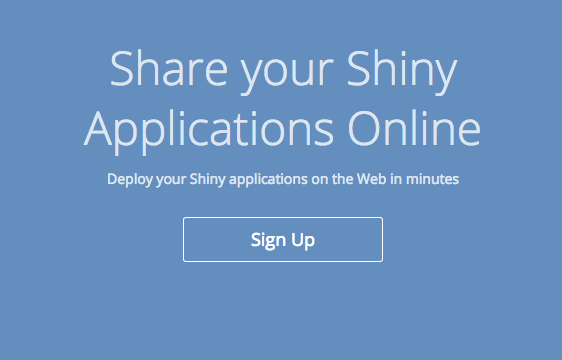

## Publish Project

### Create ShinyApps.io Account

- If you have a Google or Github Account use it
- Otherwise, fill in the information and click *Sign Up*

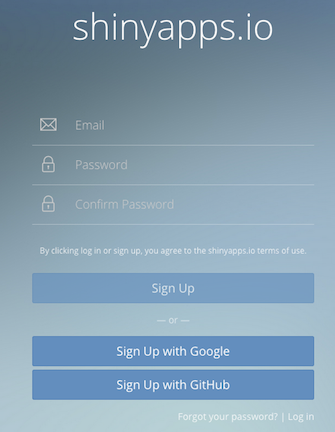

## Publish Project

### Verify Email

They'll send you an email and you have 72 hours to verify it.

*if you've never been through email verification let me be the first to welcome you to the Internet…*

## Pick Your Username

Here you might want to reflect as this will **permanently*** become part of the URL that you will use to link to your applications.

* *and by permanently I mean ephemeral because they'll let you change it later but don't because like my grandmother always said, "If you can't do something right the first time, someone else will do it for you." or something like that…*

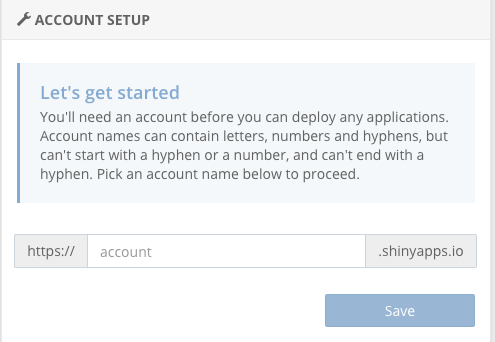

## Publish Project

### Welcome Screen

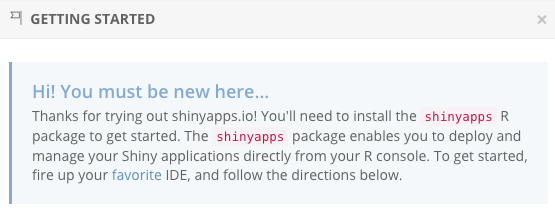

…let's review the instructions to help you install **shinyapps**

## Publish Project

### Install ShinyApps

run the following in the Console window of RStudio…

```r
if (!require("devtools"))
    install.packages("devtools")

devtools::install_github("rstudio/shinyapps")
```

and then we'll authorize your account…

## Publish Project

### Authorize Account

Now that you have Shinyapps installed we need to link it with your account.

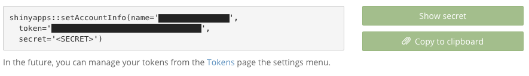

You'll need to cut-n-paste the appropriate code from the **Welcome Screen** into RStudio. In most cases that means clicking **Copy to Clipboard** and then paste but it may mean showing the secret and copying the entire thing.

*…skip step 4 on the **Welcome Screen** deploying is much easier than that…*

## Publish Project

### Publish Button

Just look for the publish button in your RStudio window…

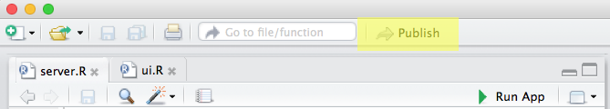

…or at the top of your running app…

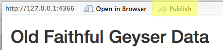

## Publish Project

### Deploy

Everything is probably filled in for you already. You should see your username and the fact that you are creating a new app selected.

The name of the app will be part of your URL so double-check that it's representative of your application before sending it over.

to proceed click **Publish**

[figure not shown]

## Intermission

{Imagine Lively Music Playing in the Background…}

[figure not shown]

## Review Your Handiwork

If all goes well - *and it doesn't always go well* - then you should be reviewing your new Shiny app in your browser. Play around with it a bit and be sure it does what you wish.

**Inevitably it won't - time to update things.**

## II. Mission: Updating Your Shiny App

*luckily this is much easier than setting up your account*

## Updating: Making Changes to Your Application

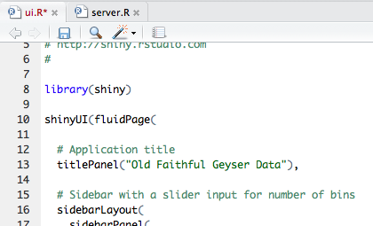

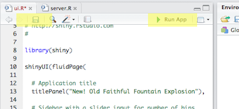

- ui.R and server.R tabs contain the respective files
- Change **titlePanel** or **label** values
- When you're done, click the blue disk icon to **save** your changes
- Run your Application -> **Run App**

## Updating: Review Changes

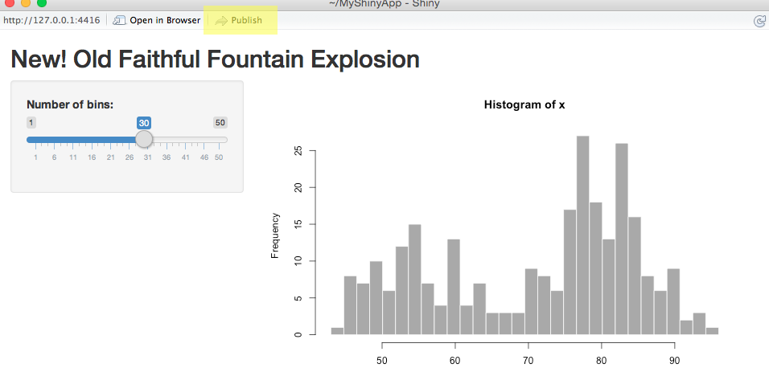

## Updating: Publish Changes

Here's a screenshot of the initial publish window…

[figure not shown]

…notice that **Create New** has changed on your window and it now wants to update your existing application…

Click **Publish**

*{**This Just In** Ralph, the wonder lama has been sacked}*

[video not shown]

## What is a Shiny Server?

### and why do I need it?

- RStudio runs a FREE ONE! (*rockin!*)
- …you can't secure it and it only runs small apps… (*I can live with that*)
- But you can install your own for FREE! (*Now We're Talking!*)
- but you have to setup your own server (*hmmm…*)
- and you still can't secure it (*fail*)
- Of course they'll sell you one that can *($ $ $ $)*

## Review Our Goals

*You have…*

- Built a New App
- Published a Shiny App
- Updated Your App

*Still Ahead…*

- Know Where to Find Information for Expanding Your App
- See How Versatile, Shiny Really Is…
- Peek into the Future to See What Shiny Will Offer…

https://yxes.github.io/Shiny_Presentation/#34

## Finding Information for Expanding Your App

- Reference Functions: http://shiny.rstudio.com/reference/shiny/latest/
- UI Widgets: http://shiny.rstudio.com/gallery/widget-gallery.html
- Example Gallery: http://shiny.rstudio.com/gallery/
- Tutorial: http://shiny.rstudio.com/tutorial/lesson1/
- Pretty Example: http://shiny.rstudio.com/gallery/superzip-example.html
- CheatSheet: http://shiny.rstudio.com/articles/cheatsheet.html

## Where can I find Shiny?

### The Invasion

### Versatility

- R-Presentation Software: https://yxes.shinyapps.io/Shiny_Presentation/
- Stand-Alone Applications: http://yxes.shinyapps.io/Capstone/
- Your personal Blog if you use… <iframe…></iframe>: http://www.statthis.com/
- RMarkdown Files: https://yxes.shinyapps.io/Officer_Involved_Shootings_Apr_2015/

## The Future

- [HTML Widgets](http://www.htmlwidgets.org/)
- [New Themes](http://bootswatch.com/)
- [Shiny Dashboard](https://almsaeedstudio.com/preview)

## Links for this Presentation…

### This Presention

- Live: http://yxes.shinyapps.io/Shiny_Presentation
- HTML View: https://yxes.github.io/Shiny_Presentation/
- GitHub Source: https://github.com/yxes/Shiny_Presentation

### Officer Involved Shootings Example

- Github: https://github.com/yxes/Officer_Involved_Shootings
- Live: http://yxes.shinyapps.io/Officer_Involved_Shootings_Apr_2015